# A holistic view of academic performance: Beyond Averages with MELSM and Spike-and-Slab

Quantitative Research Seminar - 05/02/2024

Marwin Carmo

## Motivation

- Average performance does not provide information on the *consistency* of academic achievement over time or within a cluster.
- Consider two schools with a final average grade of 75% at the year’s end:
  - In one school, students had scores ranging from 50% to 100%.
  - In the other, they maintained a steady 75%.
- Their level of mastery of different topics are almost certainly different.

## Motivation

- Inconsistent performance may reflect unaccounted factors influencing learning.
- Understanding the nature of inconsistency may shed light on systemic issues within the school environment that not only affect academic outcomes, but also contribute to students’ social and emotional development (Spörlein & Schlueter, 2018).

## Our goal

- Propose a methodology to identify clustering units (students, classrooms, etc.) that exhibit either unusually large or unusually small within-cluster variance.
- We present an adaptation of the Mixed effects location scale model (MELSM) by means of shrinking random effects to their fixed effect using the Spike and Slab regularization

## MELSM

- Educational data is classically analyzed by means of multilevel or mixed effects models (MLM):
  - Schools are level-2 units and students’ test scores are the level-1 units.
- MLM assumes constant residual variance (scale)
- MELSM include a sub-model to addresses potential differences in the residual variance.
- The unexplained residual variance might provide insights over and above the expected academic achievement that is captured in the conditional means.

## MELSM

- Does not model the residuals themselves but, instead, the error **variance** ($\sigma^2$) from which the residuals are realized.
- It *simultaneously* estimates the means and the residual variance.
- The model specifies a classic multilevel model for the observed values, $y_{ij}$ for school $j$ and student $i$, and a multilevel model for the within-cluster residual variances $\sigma^2_{\epsilon_{ij}}$.

## Advantages of MELSM

- Account for possible correlations among location and scale effects.
- Overcomes the limitations of multi-stage approaches and outperform the classic mixed effects model in in- and out of sample performance.
- Allows the inclusion of specific predictors. For example, the variability of student performance within a school can be modeled as a function of parental socioeconomic status.

The starting point is the standard linear mixed effects model for $i = 1,2,...,n_j$ students, and $j = 1, 2, \ldots, S$ schools, specified as

$$\begin{equation}
\label{eq:mixedmodel-lvl1}
\textrm{Level 1:} \quad y_{ij} = \beta_{0j} + \beta_{1j} X_{ij} + e_{ij}
\end{equation}$$

$$\begin{aligned}
\label{eq:mixedmodel-lvl2}
\textrm{Level 2:}\quad \beta_{0j} &= \gamma_{00} + \gamma_{01}W_{1j} + u_{0j} \\
\beta_{1j} &= \gamma_{10} + \gamma_{11}W_{2j} + u_{1j}
\end{aligned}$$

$$\begin{equation}
\label{eq:bcov}
\begin{pmatrix} u_0 \\ u_1 \end{pmatrix} \sim \mathcal{N}
\begin{Bmatrix}
\begin{pmatrix} 0 \\ 0 \end{pmatrix},
\begin{pmatrix} \tau^2_{u_{0}} \\ \tau_{u_{0}u_{1}} & \tau^2_{u_{1}}
\end{pmatrix}
\end{Bmatrix}
\end{equation}$$

$$\begin{equation}
e_{ij} \sim \mathcal{N} (0, \sigma_{\epsilon}^2)
\end{equation}$$

With MELSM we also allow the residual variance to differ among $i$-students within $j$-schools to obtain $\sigma^2_{\epsilon_\color{red}{ij}}$

$$\begin{equation}
\label{eq:var-lvl1}
\textrm{Level 1:} \quad \sigma^2_{\epsilon_{ij}} = \exp(\alpha_{0j} + \alpha_{1j}M_{ij})
\end{equation}$$

$$\begin{aligned}
\label{eq:var-lvl2}
\textrm{Level 2:}\quad \alpha_{0j} &= \eta_{00} + \eta_{01}P_{1j} + t_{0j} \\
\alpha_{1j} &= \eta_{10} + \eta_{11}P_{2j} + t_{1j}
\end{aligned}$$

The random effects from the *scale* and *location* of the model come from a multivariate Gaussian Normal distribution with zero means:

$$\begin{equation}
\label{eq:random-cov}
\textbf{v}=
\begin{bmatrix} u_0 \\ u_1 \\ t_0 \\ t_1 \end{bmatrix} \sim \mathcal{N}
\begin{Bmatrix}
\boldsymbol{0}=
\begin{bmatrix} 0 \\ 0 \\ 0 \\ 0 \end{bmatrix},
\boldsymbol{\Sigma}=
\begin{bmatrix} \tau^2_{u_0} \\
\tau_{u_0u_1} & \tau^2_{u_1} \\
\tau_{u_0t_0} & \tau_{u_1t_0} & \tau^2_{t_0} \\
\tau_{u_0t_1} & \tau_{u_1t_1} & \tau_{t_0t_1} & \tau^2_{t_1}
\end{bmatrix}
\end{Bmatrix}
\end{equation}$$

$$\begin{equation}
\boldsymbol{\Sigma}=
\begin{bmatrix} \tau^2_{u_0} \\
\tau_{u_0u_1} & \tau^2_{u_1} \\
\tau_{u_0t_0} & \tau_{u_1t_0} & \tau^2_{t_0} \\
\tau_{u_0t_1} & \tau_{u_1t_1} & \tau_{t_0t_1} & \tau^2_{t_1}
\end{bmatrix}
\end{equation}$$

- $\boldsymbol{\Sigma}$ can be decomposed into $\boldsymbol\Sigma = \boldsymbol{\tau}\boldsymbol{\Omega\tau}'$ to specify independent priors for each element of $\boldsymbol{\tau}$ and $\boldsymbol{\Omega}$.
- $\boldsymbol{\tau}$ is a diagonal matrix of the random-effects standard deviations.
- $\boldsymbol{\Omega}$ is the correlation matrix among all random effects.

## Cholesky transformation

Next, we can factorize $\boldsymbol\Omega$ via the Cholesky $\textbf{L}$ of $\boldsymbol\Omega = \textbf{L}'\textbf{L}$.

$$\begin{equation}
\label{eq:cholesky_approach}
\textbf{L} =
\begin{pmatrix}
1 & 0 & 0 & 0\\
\rho_{u_0u_1} & \sqrt{1 - l^2_{21}} & 0 & 0 \\
\rho_{u_0t_0} & \frac{\rho_{u_1t_0} - l_{21} l_{31}}{l_{22}} & \sqrt{1 - l^2_{31} - l^2_{32}} & 0\\
\rho_{u_0t_1} & \frac{\rho_{u_1t_1} - l_{21} l_{41}}{l_{22}} & \frac{\rho_{t_0t_1} - l_{31} l_{41} - l_{32} l_{42}}{l_{33}} & \sqrt{1 - l^2_{41} - l^2_{42} - l^2_{43}}
\end{pmatrix}
\end{equation}$$

If we multiply $\textbf{L}$ by the random effect standard deviations, $\boldsymbol{\tau}$, and scale it with a standard normally distributed $\boldsymbol{z}$, we obtain $\textbf{v}$

$$\begin{equation}
\textbf{v} = \boldsymbol{\tau}\textbf{L}\boldsymbol{z}.
\end{equation}$$

$$\begin{equation}
\begin{aligned}
u_{0j} &= \tau_{u_0}z^\mu_j\\
u_{1j} &= \tau_{u_1}(\rho_{u_{0j}u_{1j}} + \sqrt{1-l_{21}^2})z^\mu_j\\
t_{0j} &= \tau_{t_0}(\rho_{u_{0j}t_{0j}} + l_{32} + \sqrt{1-l_{31}^2-l_{32}^2})z^\sigma_j\\
t_{1j} &= \tau_{t_1}(\rho_{u_{0j}t_{1j}} + l_{42} + l_{43} + \sqrt{1-l_{41}^2-l_{31}^2-l_{32}^2})z^\sigma_j
\end{aligned}
\end{equation}$$

## Variable selection

An indicator variable ($\delta$) is included in the prior to allow switching between the spike and slab throughout the Markov Chain Monte Carlo (MCMC) sampling process.

$$\begin{equation}
\begin{aligned}
u_{0j} &= \tau_{u_0}z^\mu_j\\
u_{1j} &= \tau_{u_1}(\rho_{u_{0j}u_{1j}} + \sqrt{1-l_{21}^2})z^\mu_j\\
t_{0j} &= \tau_{t_0}\color{red}{\delta_{0j}}(\rho_{u_{0j}t_{0j}} + l_{32} + \sqrt{1-l_{31}^2-l_{32}^2})z^\sigma_j\\
t_{1j} &= \tau_{t_1}\color{red}{\delta_{1j}}(\rho_{u_{0j}t_{1j}} + l_{42} + l_{43} + \sqrt{1-l_{41}^2-l_{31}^2-l_{32}^2})z^\sigma_j
\end{aligned}
\end{equation}$$

## The Spike-and-slab approach

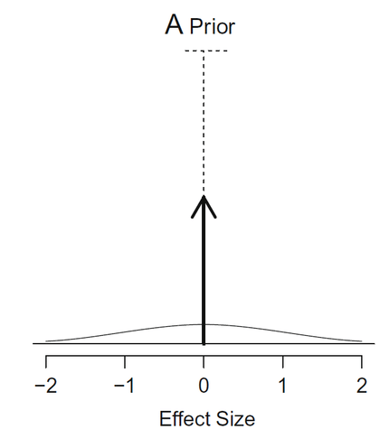

Rouder et al. (2018)

- A two component mixture
1. A “spike”, that is a Dirac measure concentrated at zero.
2. A diffuse “slab” component surrounding zero.

## The Spike-and-slab approach

- The subscript to the indicator ($\delta_j$) assigns each school a prior inclusion probability.
- For each school we obtain a probabilistic measure on whether the random effect is to be included or not.
- When a 0 is sampled, the portion after the fixed effect drops out of the equation.

$$\begin{equation}
\label{eq:mm_delta}
\alpha_{0j} = \begin{cases}
\eta_{00}, & \text{if }\delta_j = 0 , \\
\eta_{00} + t_{0j}, & \text{if }\delta_j = 1
\end{cases}.
\end{equation}$$

The posterior inclusion probabilities (PIP) can then be computed as

$$\begin{align}
Pr(\alpha_{0j} = \eta_{00} | \textbf{Y}) = 1 - \frac{1}{S} \sum_{s = 1}^S \delta_{js},
\end{align}$$

where $S = \{1,...,s\}$ denotes the posterior samples.

Assuming equal prior odds

$$\begin{align}
BF_{01} = \frac{Pr(\alpha_{0j} = \eta_{00} | \textbf{Y})}{1- Pr(\alpha_{0j} = \eta_{00} | \textbf{Y})}
\end{align}$$

## Model formulation

### Likelihood

$$\begin{align}
\label{eq:likelihood}
y_{ij} &\sim \mathcal{N}(\mu_{j}, \sigma^2_{j})\\
\mu_j &= X^\mu_{kij}\gamma_{k} + Z^\mu_{pj}u_{pj}\\
\sigma^2_j &= \exp(X^\sigma_{kij}\eta_k + Z^\sigma_{pj}t_{pj})\\
\textbf{v} &= \boldsymbol{\tau}\textbf{L}\color{red}{\boldsymbol{\delta}}\textbf{z}\\
\delta_{pj} &\sim \text{Bernoulli}(0.5)\\
z_{pj} &\sim \mathcal{N}(0, 1)
\end{align}$$

## Model formulation

### Priors

Fixed effects location:

$$\begin{equation}
\gamma_{k} \sim \mathcal{N}(0, 1000)
\end{equation}$$

Fixed effects scale:

$$\begin{equation}
\eta_{k} \sim \mathcal{N}(0, 1000)
\end{equation}$$

## Model formulation

### Priors

Random effects standard deviation:

$$\begin{equation}
\tau_{p} \sim \text{Gamma}(1, 3)
\end{equation}$$

Random effects correlation:

$$\begin{aligned}
\textbf{L} &\sim \text{LKJ}(\eta = 1)\\
\boldsymbol{\Omega} &= \textbf{L}'\textbf{L}
\end{aligned}$$

## Illustrative example

- The data for this empirical example comes from the 1982 study “High School and Beyond” (Raudenbush & Bryk, 2002)
- `mAch`: a numeric vector of Mathematics achievement scores.
- `ses`: a numeric vector of socio-economic scores.
- `sector`: a factor with levels `Public` and `Catholic`.

## Model formulation

Location

$$\begin{aligned}
\text{mAch}_{ij} &= \gamma_0 + u_{0j} + (\gamma_1 + u_{1j})\text{SES}_{ij} + \gamma_2\text{Sector}_{ij} + e_{ij}
\end{aligned}$$

$$e_{ij} \sim \mathcal{N} (0, \sigma_{\epsilon_{ij}}^2)$$

Scale

$$\begin{aligned}
\sigma_{\epsilon_{ij}}^2 = \exp(\eta_0 + t_{0j} + \eta_1 \text{SES}_{ij})
\end{aligned}$$

## Partial results

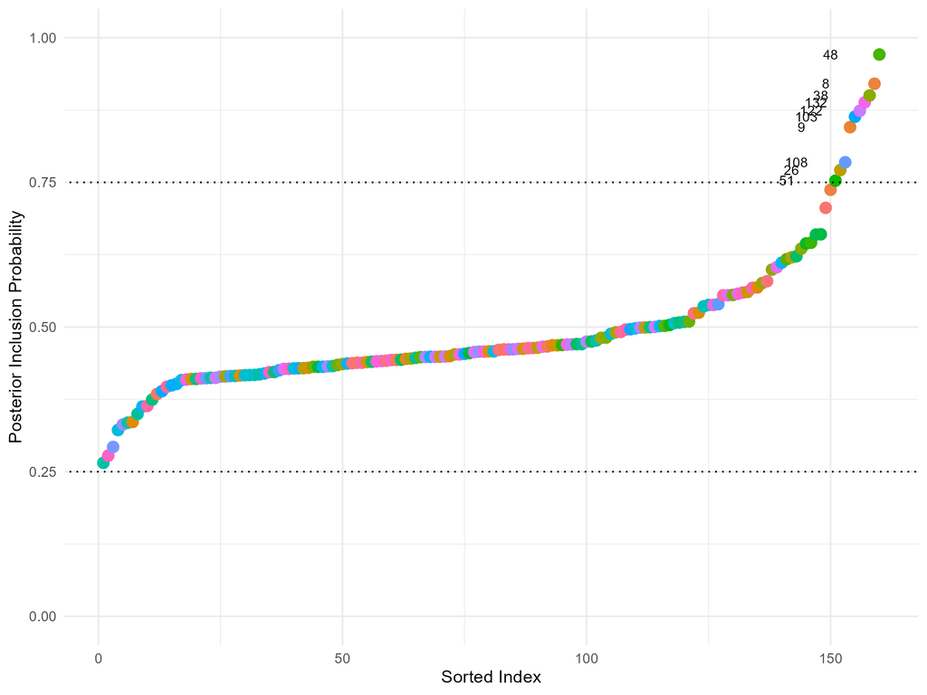

## Partial results

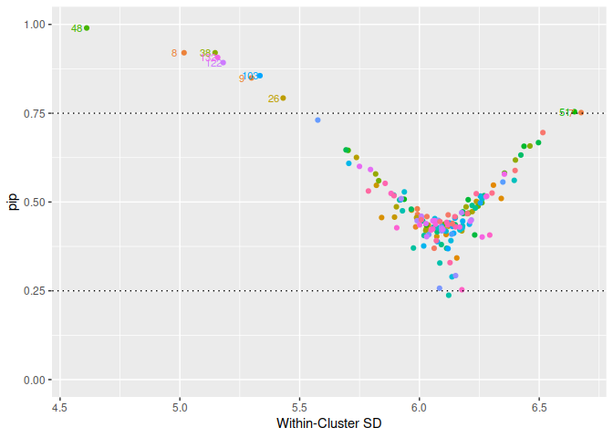

## Partial results

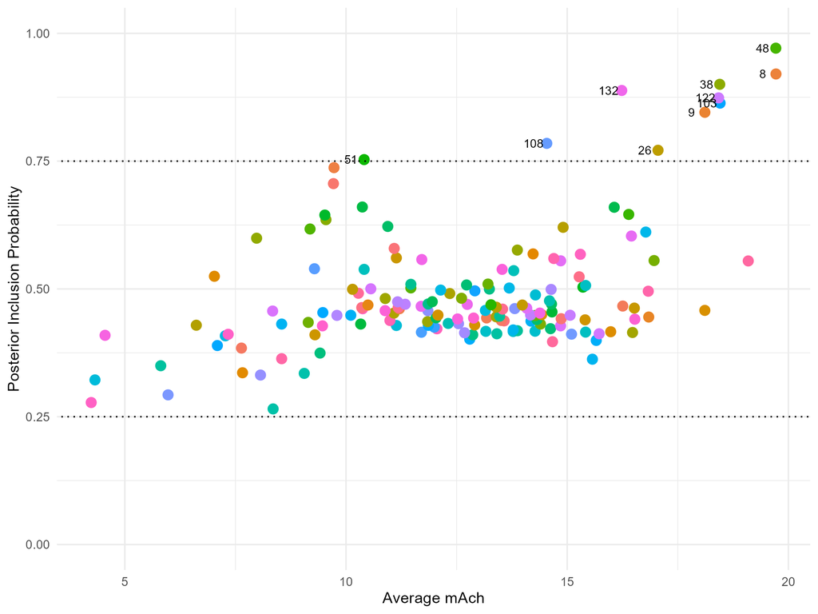

## Next steps

- Finish the `ivd` package for R.
- Build a ShinyApp to illustrate the package functionalities.
- Communicate the results to the scientific community.

Beyond Averages with MELSM and Spike-and-Slab